# Project: TMDB Movies Analysis

- Introduction
- Data Wrangling
- Exploratory Data Analysis
- Conclusions

## Introduction

```python
# Software used in this project are imported here.
import pandas as pd
import numpy as np
import matplotlib.pyplot as plt
%matplotlib inline
```

## Data Wrangling

> In this section, I will preliminarily check the raw data and eliminate some useless columns such as director, tagline and etc. Also, I will dorp the duplicated data.

### General Properties

```python
# raw data are imported here.
df_raw = pd.read_csv('tmdb-movies.csv')
df_raw.head()
```

|  | id | imdb_id | popularity | budget | revenue | original_title | cast | homepage | director | tagline | ... | overview | runtime | genres | production_companies | release_date | vote_count | vote_average | release_year | budget_adj | revenue_adj |
| --- | --- | --- | --- | --- | --- | --- | --- | --- | --- | --- | --- | --- | --- | --- | --- | --- | --- | --- | --- | --- | --- |
| 0 | 135397 | tt0369610 | 32.985763 | 150000000 | 1513528810 | Jurassic World | Chris Pratt\|Bryce Dallas Howard\|Irrfan Khan\|Vi... | http://www.jurassicworld.com/ | Colin Trevorrow | The park is open. | ... | Twenty-two years after the events of Jurassic ... | 124 | Action\|Adventure\|Science Fiction\|Thriller | Universal Studios\|Amblin Entertainment\|Legenda... | 6/9/15 | 5562 | 6.5 | 2015 | 1.379999e+08 | 1.392446e+09 |
| 1 | 76341 | tt1392190 | 28.419936 | 150000000 | 378436354 | Mad Max: Fury Road | Tom Hardy\|Charlize Theron\|Hugh Keays-Byrne\|Nic... | http://www.madmaxmovie.com/ | George Miller | What a Lovely Day. | ... | An apocalyptic story set in the furthest reach... | 120 | Action\|Adventure\|Science Fiction\|Thriller | Village Roadshow Pictures\|Kennedy Miller Produ... | 5/13/15 | 6185 | 7.1 | 2015 | 1.379999e+08 | 3.481613e+08 |
| 2 | 262500 | tt2908446 | 13.112507 | 110000000 | 295238201 | Insurgent | Shailene Woodley\|Theo James\|Kate Winslet\|Ansel... | http://www.thedivergentseries.movie/#insurgent | Robert Schwentke | One Choice Can Destroy You | ... | Beatrice Prior must confront her inner demons ... | 119 | Adventure\|Science Fiction\|Thriller | Summit Entertainment\|Mandeville Films\|Red Wago... | 3/18/15 | 2480 | 6.3 | 2015 | 1.012000e+08 | 2.716190e+08 |
| 3 | 140607 | tt2488496 | 11.173104 | 200000000 | 2068178225 | Star Wars: The Force Awakens | Harrison Ford\|Mark Hamill\|Carrie Fisher\|Adam D... | http://www.starwars.com/films/star-wars-episod... | J.J. Abrams | Every generation has a story. | ... | Thirty years after defeating the Galactic Empi... | 136 | Action\|Adventure\|Science Fiction\|Fantasy | Lucasfilm\|Truenorth Productions\|Bad Robot | 12/15/15 | 5292 | 7.5 | 2015 | 1.839999e+08 | 1.902723e+09 |
| 4 | 168259 | tt2820852 | 9.335014 | 190000000 | 1506249360 | Furious 7 | Vin Diesel\|Paul Walker\|Jason Statham\|Michelle ... | http://www.furious7.com/ | James Wan | Vengeance Hits Home | ... | Deckard Shaw seeks revenge against Dominic Tor... | 137 | Action\|Crime\|Thriller | Universal Pictures\|Original Film\|Media Rights ... | 4/1/15 | 2947 | 7.3 | 2015 | 1.747999e+08 | 1.385749e+09 |

5 rows × 21 columns

```python
# There are 10866 rowa and 21 columns in this data set
df_raw.shape
```

```
(10866, 21)
```

```python
# Some statistical information of this data set
df_raw.describe()
```

|  | id | popularity | budget | revenue | runtime | vote_count | vote_average | release_year | budget_adj | revenue_adj |
| --- | --- | --- | --- | --- | --- | --- | --- | --- | --- | --- |
| count | 10866.000000 | 10866.000000 | 1.086600e+04 | 1.086600e+04 | 10866.000000 | 10866.000000 | 10866.000000 | 10866.000000 | 1.086600e+04 | 1.086600e+04 |
| mean | 66064.177434 | 0.646441 | 1.462570e+07 | 3.982332e+07 | 102.070863 | 217.389748 | 5.974922 | 2001.322658 | 1.755104e+07 | 5.136436e+07 |
| std | 92130.136561 | 1.000185 | 3.091321e+07 | 1.170035e+08 | 31.381405 | 575.619058 | 0.935142 | 12.812941 | 3.430616e+07 | 1.446325e+08 |
| min | 5.000000 | 0.000065 | 0.000000e+00 | 0.000000e+00 | 0.000000 | 10.000000 | 1.500000 | 1960.000000 | 0.000000e+00 | 0.000000e+00 |
| 25% | 10596.250000 | 0.207583 | 0.000000e+00 | 0.000000e+00 | 90.000000 | 17.000000 | 5.400000 | 1995.000000 | 0.000000e+00 | 0.000000e+00 |
| 50% | 20669.000000 | 0.383856 | 0.000000e+00 | 0.000000e+00 | 99.000000 | 38.000000 | 6.000000 | 2006.000000 | 0.000000e+00 | 0.000000e+00 |
| 75% | 75610.000000 | 0.713817 | 1.500000e+07 | 2.400000e+07 | 111.000000 | 145.750000 | 6.600000 | 2011.000000 | 2.085325e+07 | 3.369710e+07 |
| max | 417859.000000 | 32.985763 | 4.250000e+08 | 2.781506e+09 | 900.000000 | 9767.000000 | 9.200000 | 2015.000000 | 4.250000e+08 | 2.827124e+09 |

> As we can see from the table above, half of the adjusted budget and revenue amounts are zero whiches are abnomal. So these rows with zero adjusted budget and revenue should be eliminated when analyzing budgets and revenue.

### Data Cleaning (eliminate useless colums and duplicates)

```python
# Some irrelevant columns are dropped
df_raw.info()
drop_list = ['id','imdb_id','budget','revenue','original_title','cast','homepage','director','tagline','keywords','overview','release_year']
```

```
<class 'pandas.core.frame.DataFrame'>
RangeIndex: 10866 entries, 0 to 10865
Data columns (total 21 columns):
id                      10866 non-null int64
imdb_id                 10856 non-null object
popularity              10866 non-null float64
budget                  10866 non-null int64
revenue                 10866 non-null int64
original_title          10866 non-null object
cast                    10790 non-null object
homepage                2936 non-null object
director                10822 non-null object
tagline                 8042 non-null object
keywords                9373 non-null object
overview                10862 non-null object
runtime                 10866 non-null int64
genres                  10843 non-null object
production_companies    9836 non-null object
release_date            10866 non-null object
vote_count              10866 non-null int64
vote_average            10866 non-null float64
release_year            10866 non-null int64
budget_adj              10866 non-null float64
revenue_adj             10866 non-null float64
dtypes: float64(4), int64(6), object(11)
memory usage: 1.7+ MB
```

```python
# The data set that we need to use
df_useful = df_raw.drop(drop_list,axis=1)
df_useful.head()
```

|  | popularity | runtime | genres | production_companies | release_date | vote_count | vote_average | budget_adj | revenue_adj |
| --- | --- | --- | --- | --- | --- | --- | --- | --- | --- |
| 0 | 32.985763 | 124 | Action\|Adventure\|Science Fiction\|Thriller | Universal Studios\|Amblin Entertainment\|Legenda... | 6/9/15 | 5562 | 6.5 | 1.379999e+08 | 1.392446e+09 |
| 1 | 28.419936 | 120 | Action\|Adventure\|Science Fiction\|Thriller | Village Roadshow Pictures\|Kennedy Miller Produ... | 5/13/15 | 6185 | 7.1 | 1.379999e+08 | 3.481613e+08 |
| 2 | 13.112507 | 119 | Adventure\|Science Fiction\|Thriller | Summit Entertainment\|Mandeville Films\|Red Wago... | 3/18/15 | 2480 | 6.3 | 1.012000e+08 | 2.716190e+08 |
| 3 | 11.173104 | 136 | Action\|Adventure\|Science Fiction\|Fantasy | Lucasfilm\|Truenorth Productions\|Bad Robot | 12/15/15 | 5292 | 7.5 | 1.839999e+08 | 1.902723e+09 |
| 4 | 9.335014 | 137 | Action\|Crime\|Thriller | Universal Pictures\|Original Film\|Media Rights ... | 4/1/15 | 2947 | 7.3 | 1.747999e+08 | 1.385749e+09 |

```python
df_useful.to_csv('tmbd_movies_ed1.csv',index=False)
```

```python
df_useful.info()
```

```
<class 'pandas.core.frame.DataFrame'>
RangeIndex: 10866 entries, 0 to 10865
Data columns (total 9 columns):
popularity              10866 non-null float64
runtime                 10866 non-null int64
genres                  10843 non-null object
production_companies    9836 non-null object
release_date            10866 non-null object
vote_count              10866 non-null int64
vote_average            10866 non-null float64
budget_adj              10866 non-null float64
revenue_adj             10866 non-null float64
dtypes: float64(4), int64(2), object(3)
memory usage: 764.1+ KB
```

```python
# check duplicates
sum(df_useful.duplicated())
```

```
1
```

```python
# Drop duplicates
df_useful.drop_duplicates(inplace=True)
sum(df_useful.duplicated())
```

```
0
```

## Exploratory Data Analysis

### Question 1 Movies release in which monthes are relatively popular, high rating and gain high revenues?

> In this question, I will discuss three relationships. Respectively, they are the relationship between month and popularity, the relationship between month and ratins and the relationship between month and revenues.

```python
# change the column release_date to release_month
df_m_1 = df_useful.copy()
df_m_2 = df_useful.copy()
df_m_3 = df_useful.copy()
```

```python
split_columns = ['release_date']
for c in split_columns:
    df_m_1[c] = df_m_1[c].apply(lambda x:x.split("/")[0])
df_m_1.head()
```

|  | popularity | runtime | genres | production_companies | release_date | vote_count | vote_average | budget_adj | revenue_adj |
| --- | --- | --- | --- | --- | --- | --- | --- | --- | --- |
| 0 | 32.985763 | 124 | Action\|Adventure\|Science Fiction\|Thriller | Universal Studios\|Amblin Entertainment\|Legenda... | 6 | 5562 | 6.5 | 1.379999e+08 | 1.392446e+09 |
| 1 | 28.419936 | 120 | Action\|Adventure\|Science Fiction\|Thriller | Village Roadshow Pictures\|Kennedy Miller Produ... | 5 | 6185 | 7.1 | 1.379999e+08 | 3.481613e+08 |
| 2 | 13.112507 | 119 | Adventure\|Science Fiction\|Thriller | Summit Entertainment\|Mandeville Films\|Red Wago... | 3 | 2480 | 6.3 | 1.012000e+08 | 2.716190e+08 |
| 3 | 11.173104 | 136 | Action\|Adventure\|Science Fiction\|Fantasy | Lucasfilm\|Truenorth Productions\|Bad Robot | 12 | 5292 | 7.5 | 1.839999e+08 | 1.902723e+09 |
| 4 | 9.335014 | 137 | Action\|Crime\|Thriller | Universal Pictures\|Original Film\|Media Rights ... | 4 | 2947 | 7.3 | 1.747999e+08 | 1.385749e+09 |

```python
df_m_1.rename(columns={'release_date':'release_month'},inplace=True)
df_m_1.head()
```

|  | popularity | runtime | genres | production_companies | release_month | vote_count | vote_average | budget_adj | revenue_adj |
| --- | --- | --- | --- | --- | --- | --- | --- | --- | --- |
| 0 | 32.985763 | 124 | Action\|Adventure\|Science Fiction\|Thriller | Universal Studios\|Amblin Entertainment\|Legenda... | 6 | 5562 | 6.5 | 1.379999e+08 | 1.392446e+09 |
| 1 | 28.419936 | 120 | Action\|Adventure\|Science Fiction\|Thriller | Village Roadshow Pictures\|Kennedy Miller Produ... | 5 | 6185 | 7.1 | 1.379999e+08 | 3.481613e+08 |
| 2 | 13.112507 | 119 | Adventure\|Science Fiction\|Thriller | Summit Entertainment\|Mandeville Films\|Red Wago... | 3 | 2480 | 6.3 | 1.012000e+08 | 2.716190e+08 |
| 3 | 11.173104 | 136 | Action\|Adventure\|Science Fiction\|Fantasy | Lucasfilm\|Truenorth Productions\|Bad Robot | 12 | 5292 | 7.5 | 1.839999e+08 | 1.902723e+09 |
| 4 | 9.335014 | 137 | Action\|Crime\|Thriller | Universal Pictures\|Original Film\|Media Rights ... | 4 | 2947 | 7.3 | 1.747999e+08 | 1.385749e+09 |

```python
df_m_1.to_csv('tmbd_movie_q1.csv', index=False)
```

```python
df1=pd.read_csv('tmbd_movie_q1.csv')
```

```python
# The average popularity score and ratings grouping by months.
res = df1.groupby('release_month')['popularity','vote_average'].mean()
res
```

| release_month | popularity | vote_average |
| --- | --- | --- |
| 1 | 0.460574 | 5.870620 |
| 2 | 0.589931 | 5.918524 |
| 3 | 0.642808 | 5.928102 |
| 4 | 0.562475 | 5.875533 |
| 5 | 0.749997 | 5.967985 |
| 6 | 0.800755 | 6.012092 |
| 7 | 0.747678 | 5.928411 |
| 8 | 0.584363 | 5.840087 |
| 9 | 0.564820 | 6.068069 |
| 10 | 0.613168 | 5.959844 |
| 11 | 0.755466 | 6.062654 |
| 12 | 0.750784 | 6.189442 |

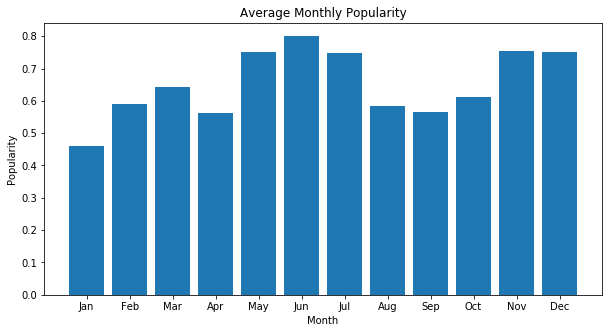

```python
# Bar chat-Average Monthly Popularity
ind = [i for i in range(12)]
heights = res['popularity']
labels = ['Jan', 'Feb', 'Mar', 'Apr', 'May', 'Jun', 'Jul', 'Aug', 'Sep', 'Oct', 'Nov', 'Dec']
plt.figure(figsize=(10, 5))
plt.bar(ind, heights, width=0.8, tick_label=labels)
plt.xlabel('Month')
plt.ylabel('Popularity')
plt.title('Average Monthly Popularity')
plt.show()
```

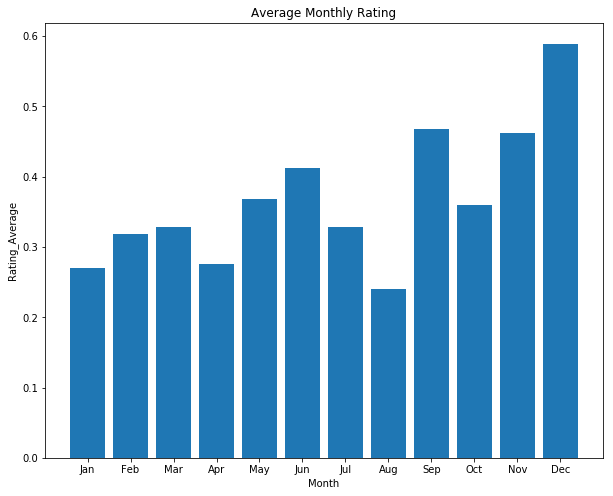

```python
# Bar chat-Average Monthly Rating
ind = [i for i in range(12)]
heights = res['vote_average'] - 5.6
labels = ['Jan', 'Feb', 'Mar', 'Apr', 'May', 'Jun', 'Jul', 'Aug', 'Sep', 'Oct', 'Nov', 'Dec']
plt.figure(figsize=(10, 8))
plt.bar(ind, heights, width=0.8, tick_label=labels)
plt.xlabel('Month')
plt.ylabel('Rating_Average')
plt.title('Average Monthly Rating')
plt.show()
# As we can see from the table above, all the monthly average rating scores are above 5.6, so I deducted
# all the rating scores by 5.6 in order to generate a more clear vision in comparing the differences.
```

```python
# As I mentioned above in the data cleaning part, half of the adjusted revenue amounts are zero,
# so these data are eliminated in this part.
revenue_useful= df1.query('revenue_adj!=0')
revenue_useful.head()
revenue_useful.to_csv('revenue_useful.csv',index=False)
```

```python
# Average adjusted revenues grouping by month
df2=pd.read_csv('revenue_useful.csv')
rev = df2.groupby('release_month')['revenue_adj'].mean()
rev
```

```
release_month
1     5.766574e+07
2     7.260786e+07
3     1.096817e+08
4     9.175031e+07
5     1.667118e+08
6     1.968615e+08
7     1.525010e+08
8     7.554500e+07
9     5.083392e+07
10    8.430962e+07
11    1.615969e+08
12    1.717964e+08
Name: revenue_adj, dtype: float64
```

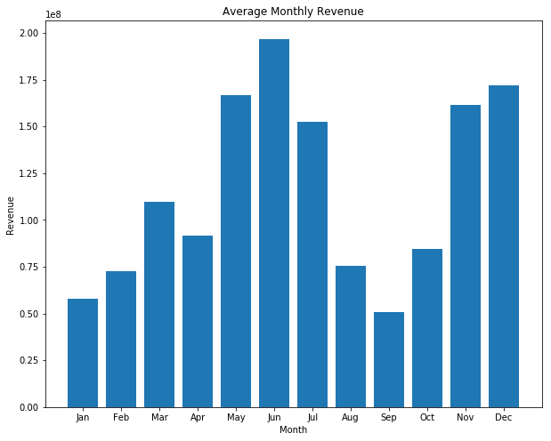

```python
# Bar chart - Average Monthly Revenue
ind = [i for i in range(12)]
heights = rev
labels = ['Jan', 'Feb', 'Mar', 'Apr', 'May', 'Jun', 'Jul', 'Aug', 'Sep', 'Oct', 'Nov', 'Dec']
plt.figure(figsize=(10, 8))
plt.bar(ind, heights, width=0.8, tick_label=labels)
plt.xlabel('Month')
plt.ylabel('Revenue')
plt.title('Average Monthly Revenue')
plt.show()
```

> As we can easily tell from the three bar charts above, the movies release in June, November and December are tended to have high revenues and popularities. More over, relatively more high rating movies are releasing in the end of the year(November and December.)